# Intro To R Final Project

Conor Falvey

10/31/2019

Our motivation for this project came from all three of us sharing a common interest in machine learning.  
Since all three of us come from different backgrounds and speak multiple languages, we had to  
establish an affective way to communicate when deciding what our project was going to be. During our  
meetings, we started to notice how similar some English words are to some of the words in our respective  
languages. This then steered us into natural language processing using machine learning as we wanted to  
learn more about the origins of the English language.

The biggest problem we face by far, is trying to generalize a single word into just one category.  
There are plenty of words in the English language the originate from multiple languages as opposed to  
just one. Although we can make our neural network to take into account all the different languages a  
word might originate from, there are just too many outlying factors to take care of that can make our  
inference 100% correct and free from error.

Packages we used for this project:

```r
knitr::opts_chunk$set(echo = TRUE)
library(class)
library(neuralnet)
library(gtools)
library(stringr)
library(SnowballC)
```

One of the main things we learned from this project is how powerful neural networks can be. They’re not  
the most friendly to work with, however, they epitomize the whole concept of machine learning. Starting  
off by training a computer to recognize small patterns, we can quickly create an selection of different  
possibilities that can lead to some really interesting results. Neural networks are also useful in a  
sense that they can give a fairly accurate result even when given sub-par knowledge because they build  
upon prior inferences.  
One thing we could improve about this project is have more accurate and fixed data sets. Since we created  
our own datasets from a wikipedia page, it’s not the best. However, that is one of the struggles when  
evaluating the origins of a language, there’s only a handful of information you can find online, becuase  
language itself is so complex. Thus, we had to settle for creating our own datasets.

## Label Data

```r
words <- readLines("./10k.txt")
anglo <- readLines("./anglo.txt")
norse <- readLines("./oldnorse.txt")
french <- readLines("./french.txt")
latin <- readLines("./latin.txt")

labels <- c("word", "ety")
words <- setdiff(setdiff(setdiff(setdiff(words, anglo), norse), french), latin)

no.label <- data.frame(words, rep(0, length(words)))
anglo.df <- data.frame(anglo, rep(1, length(anglo)))
norse.df <- data.frame(norse, rep(2, length(norse)))
french.df <- data.frame(french, rep(3, length(french)))
latin.df <- data.frame(latin, rep(4, length(latin)))

names(no.label) <- labels
names(anglo.df) <- labels
names(norse.df) <- labels
names(french.df) <- labels
names(latin.df) <- labels

data <- rbind(rbind(rbind(rbind(no.label, anglo.df), norse.df), french.df), latin.df)
data[, 1] <- tolower(data[, 1])
data <- data[-1, ]
```

## Getting Statistics

```r
for (i in 1:length(data$word)) {
  data[i, 3] <- sum(asc(data[i, 1])) / str_length(data[i, 1])
  data[i, 4] <- wordStem(data[i, 1], language = "english")
  data[i, 5] <- sum(asc(data[i, 4])) / str_length(data[i, 4])
  data[i, 6] <- data[i, 5] - data[i, 3]
}

labels <- c("word", "ety", "score", "stem", "stemScore", "diff")
names(data) <- labels

numerics <- data.frame(data[, 2], data[, 3], data[, 5], data[, 6])
names(numerics) <- c("ety", "score", "stemScore", "diff")
```

## Planning Neural Network

```r
#Split dataset for testing and training
index <- sample(1:nrow(numerics),round(0.75*nrow(numerics)))
train <- numerics[index,]
test <- numerics[-index,]

#Create linear model to test error against
lm.fit <- glm(train$ety ~ ., data=train)
summary(lm.fit)
```

```
##
## Call:
## glm(formula = train$ety ~ ., data = train)
##
## Deviance Residuals:
##     Min       1Q   Median       3Q      Max
## -5.2758  -1.7584   0.9796   1.1204   2.4449
##
## Coefficients: (1 not defined because of singularities)
##             Estimate Std. Error t value Pr(>|t|)
## (Intercept) -3.41918    0.40927  -8.354  < 2e-16 ***
## score        0.08743    0.01134   7.707 1.36e-14 ***
## stemScore   -0.02857    0.01062  -2.689  0.00717 **
## diff              NA         NA      NA       NA
## ---
## Signif. codes:  0 '***' 0.001 '**' 0.01 '*' 0.05 '.' 0.1 ' ' 1
##
## (Dispersion parameter for gaussian family taken to be 2.524497)
##
##     Null deviance: 42103  on 16435  degrees of freedom
## Residual deviance: 41485  on 16433  degrees of freedom
## AIC: 61869
##
## Number of Fisher Scoring iterations: 2
```

```r
pr.lm <- predict(lm.fit,test)
MSE.lm <- sum((pr.lm - test$ety)^2)/nrow(test)

#Scale data to standardized input set
maxs <- apply(numerics, 2, max)
mins <- apply(numerics, 2, min)

scaled <- as.data.frame(scale(numerics, center = mins, scale = maxs - mins))

train_ <- scaled[index,]
test_ <- scaled[-index,]
```

## Running Network

```r
# Set names of columns in neural network
n <- names(train_)

# Create formula for use in network
f <- as.formula(paste("train_$ety ~", paste(n[!n %in% "ety"], collapse = " + ")))

# Run the network!
nn <- neuralnet(f, data = train_, hidden = c(5, 5, 3, 3), linear.output = T, threshold = 0.1, stepmax = 1e6)

# Test with testing set
pr.nn <- compute(nn, test_[ ,1:4])

# Compute the error of the network
pr.nn_ <- pr.nn$net.result*(max(numerics$ety)-min(numerics$ety))+min(numerics$ety)
test.r <- (test_$ety)*(max(numerics$ety)-min(numerics$ety))+min(numerics$ety)

MSE.nn <- sum((test.r - pr.nn_)^2)/nrow(test_)

# Compare how effective it is versus a linear model
print(paste(MSE.lm,MSE.nn))
```

```
## [1] "2.4680629187414 2.43614694555715"
```

## Function wrapper

```r
testNetwork <- function(word) {
  score <- sum(asc(word)) / str_length(word)
  stemScore <- sum(asc(wordStem(word, language = "english"))) /
    str_length(wordStem(word, language = "english"))
  difference <- stemScore - score

  tester <- data.frame(word, score, stemScore, difference)
  names(tester) <- c("ety", "score", "stemScore", "diff")

  comp <- compute(nn, tester)
  print(comp$net.result * 4)
}
```

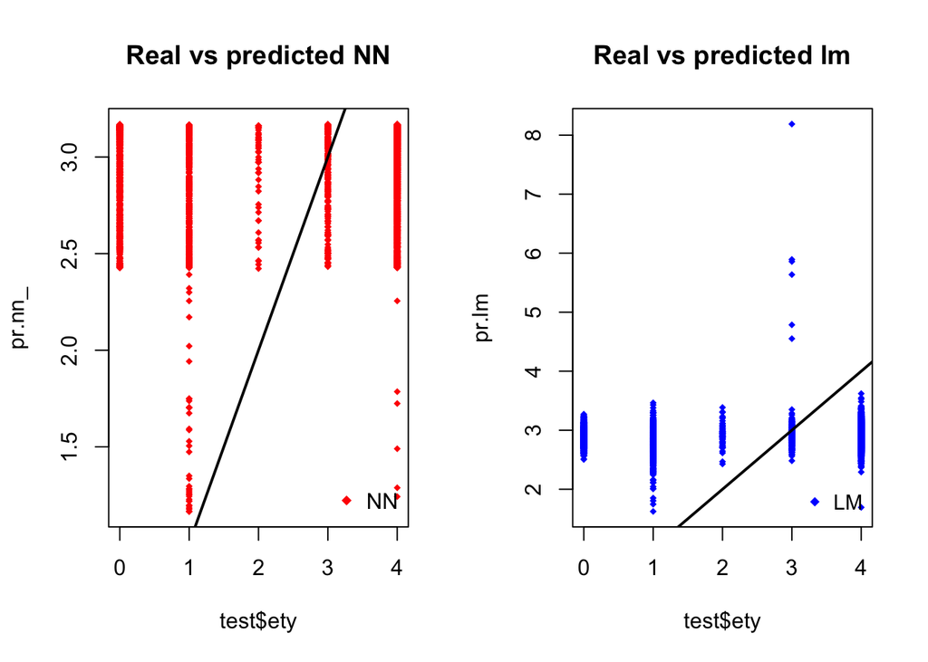

```r
par(mfrow=c(1,2))

plot(test$ety, pr.nn_, col = 'red', main = 'Real vs predicted NN', pch = 18, cex = 0.7)
abline(0, 1, lwd = 2)
legend('bottomright', legend = 'NN', pch = 18, col = 'red', bty = 'n')

plot(test$ety, pr.lm, col = 'blue', main = 'Real vs predicted lm', pch = 18, cex = 0.7)
abline(0, 1, lwd = 2)
legend('bottomright', legend = 'LM', pch = 18, col = 'blue', bty = 'n', cex = .95)
```

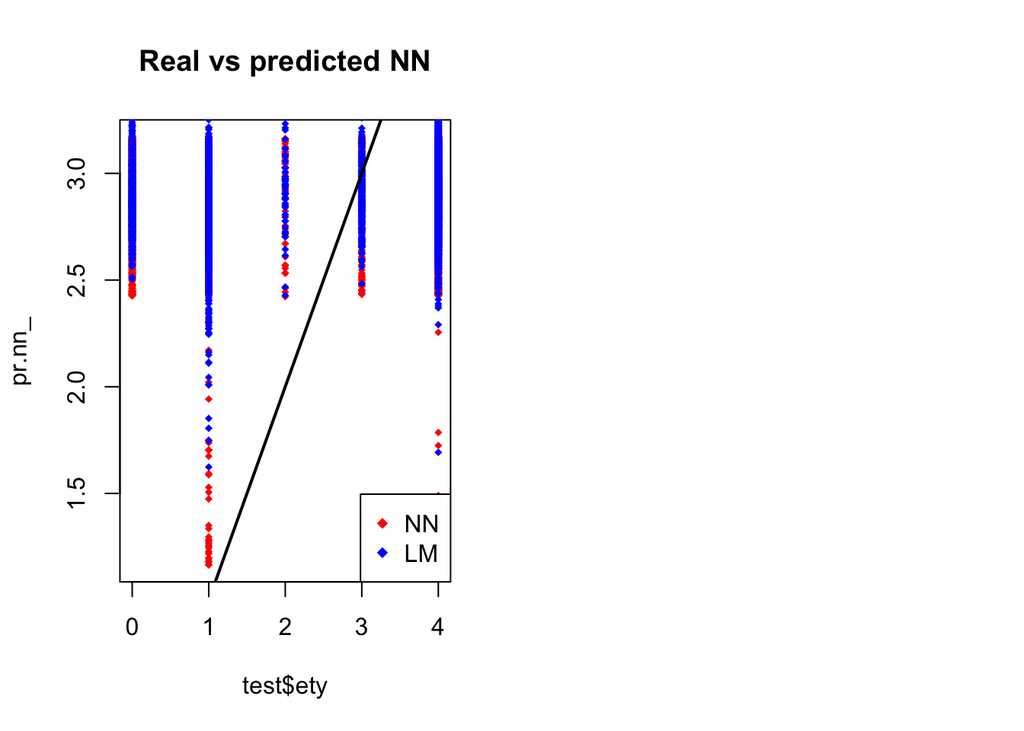

```r
plot(test$ety, pr.nn_, col = 'red', main = 'Real vs predicted NN', pch = 18, cex = 0.7)
points(test$ety, pr.lm, col = 'blue', pch = 18, cex = 0.7)
abline(0, 1, lwd = 2)
legend('bottomright', legend = c('NN','LM'), pch = 18, col = c('red','blue'))


#Don't use: This adds variablilty to exagerate results
testNetwork <- function(word) {
  score <- sum(asc(word)) / str_length(word)
  stemScore <- sum(asc(wordStem(word, language = "english"))) /
    str_length(wordStem(word, language = "english"))
  difference <- stemScore - score

  tester <- data.frame(word, score, stemScore, difference)
  names(tester) <- c("ety", "score", "stemScore", "diff")

  comp <- compute(nn, tester)
  compMid <- comp$net.result + runif(1, -0.5, 0.5)
  print(compMid * 4)
}
```